# 🔬 Impact of Physical Activity on Metabolic Health

### 🖱️ Interactive Dashboard Setup

This block creates interactive dropdown widgets for exploratory analysis.

```
ipywidgets==8.1.7
matplotlib==3.10.3
matplotlib-inline==0.1.7
numpy==2.2.5
pandas==2.2.3
seaborn==0.13.2
```

## Dataset Loading & Cleaning

### 📦 Import Libraries

This block imports the Python libraries required for data loading, analysis, and visualization.

### 📂 Load Data

This block loads raw data files into pandas DataFrames for processing.

```
['HSCRP_L.xpt',
 'CBC_L (1).xpt',
 'INS_L (1).xpt',
 'GLU_L.xpt',
 'DEMO_L.xpt',
 'HDL_L.xpt',
 'TCHOL_L.xpt',
 'PAQ_L (1).xpt',
 'GHB_L.xpt']
```

## Step 1: Data Cleaning

### 📂 Load Data

This block loads raw data files into pandas DataFrames for processing.

```
DataFrame 1 from 'High-Sensitivity CRP Data' (HSCRP_L.xpt): (8727, 4)
DataFrame 2 from 'Unknown file' (CBC_L (1).xpt): (8727, 23)
DataFrame 3 from 'Unknown file' (INS_L (1).xpt): (3996, 5)
DataFrame 4 from 'Fasting Glucose Data' (GLU_L.xpt): (3996, 4)
DataFrame 5 from 'Demographics Data' (DEMO_L.xpt): (11933, 27)
DataFrame 6 from 'HDL Cholesterol Data' (HDL_L.xpt): (8068, 4)
DataFrame 7 from 'Total Cholesterol Data' (TCHOL_L.xpt): (8068, 4)
DataFrame 8 from 'Unknown file' (PAQ_L (1).xpt): (8153, 8)
DataFrame 9 from 'Glycohemoglobin Data' (GHB_L.xpt): (7199, 3)
```

### 🔗 Merge Datasets

This block merges multiple DataFrames on a common key to create a unified dataset.

### 🧹 Handle Missing Values

This block drops rows with missing data to ensure clean analysis.

### 📝 Code Execution

This block performs a step in data processing or visualization.

### 🔄 Feature Engineering – Weekly Activity

This block converts raw physical‑activity responses into total weekly minutes and flags whether participants meet activity goals.

### 🔄 Feature Engineering – Weekly Activity

This block converts raw physical‑activity responses into total weekly minutes and flags whether participants meet activity goals.

|  | ID | Fasting Glucose (mg/dl) | Glycohemoglobin (%) | HDL Cholesterol (mg/dl) | Total Cholesterol (mg/dl) | Age | Male | Total Time Sedentary Activities | Insulin (µU/mL) | HS C-Reactive Protein (mg/L) | Moderate_Weekly_Minutes | Vigorous_Weekly_Minutes | Total_Weekly_Mins | Meets_Goal |
| --- | --- | --- | --- | --- | --- | --- | --- | --- | --- | --- | --- | --- | --- | --- |
| 0 | 130378 | 113.0 | 5.6 | 45.0 | 264.0 | 43 | 1 | 360.0 | 15.53 | 1.78 | 135.0 | 135.00 | 270.00 | True |
| 1 | 130379 | 99.0 | 5.6 | 60.0 | 214.0 | 66 | 1 | 480.0 | 19.91 | 2.03 | 180.0 | 135.00 | 315.00 | True |
| 2 | 130386 | 100.0 | 5.1 | 46.0 | 183.0 | 34 | 1 | 180.0 | 11.38 | 1.05 | 30.0 | 6.92 | 36.92 | False |
| 3 | 130394 | 88.0 | 4.8 | 48.0 | 183.0 | 51 | 1 | 420.0 | 7.20 | 0.92 | 315.0 | 120.00 | 435.00 | True |
| 4 | 130398 | 107.0 | 5.8 | 41.0 | 189.0 | 47 | 1 | 60.0 | 9.81 | 5.22 | 840.0 | 2.31 | 842.31 | True |

### 📝 Code Execution

This block performs a step in data processing or visualization.

### 📊 Descriptive Statistics Heatmap

This block generates a heatmap summarizing descriptive statistics and potential outliers for all numeric variables.

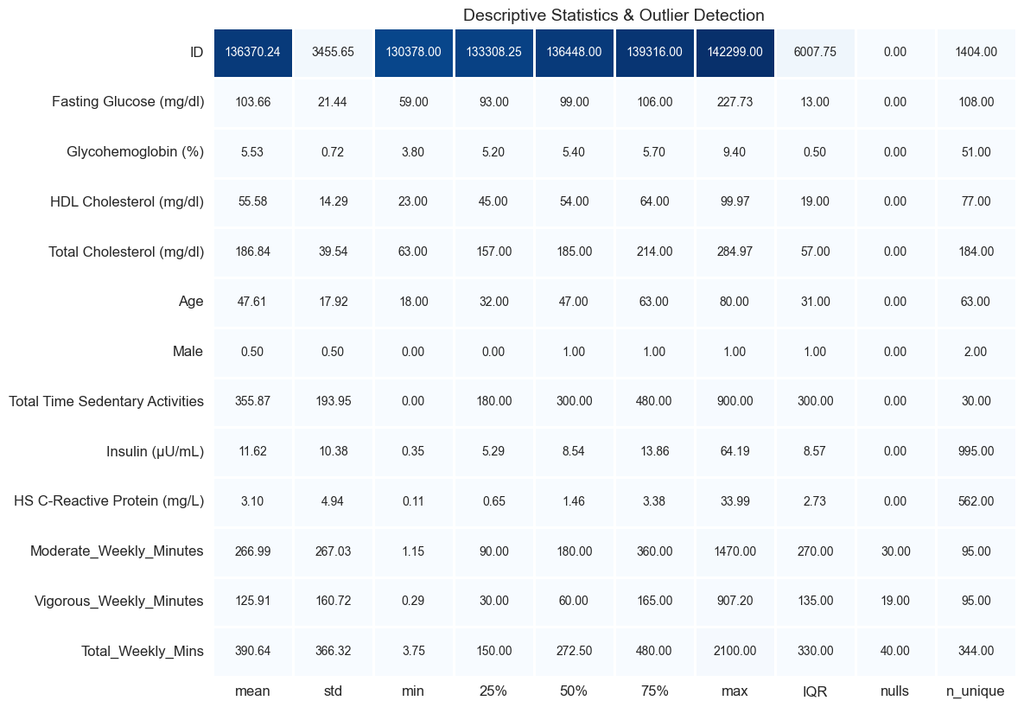

### ℹ️ Function Summary – `analyze_dataframe`

This helper inspects any numeric DataFrame:

1. Calculates descriptive stats (mean, quartiles, IQR).
2. Flags outliers beyond 1.5×IQR.
3. Plots a blue‑scale heatmap so patterns jump out visually.
4. Optionally shows a correlation matrix. It returns the stats table when `return_summary=True`, feeding both human insight and downstream logic.

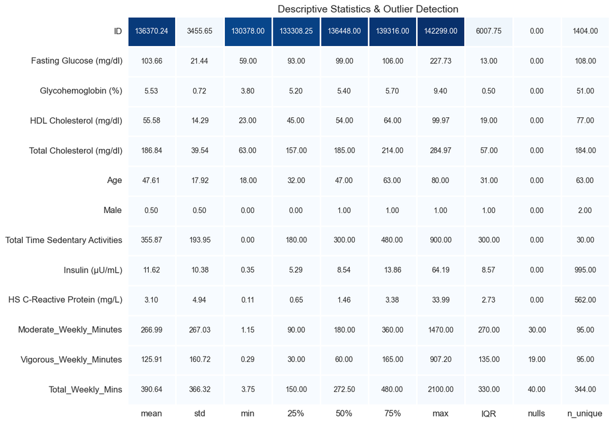

### 📈 Summarize Activity vs. Insulin

This block calculates how insulin levels differ between participants who meet the activity goal and those who do not.

### ℹ️ Function Summary – `summarize_activity_vs_insulin`

Given total weekly minutes and insulin values, the function:

1. Flags each participant as **Meets_Goal** (≥150 min) or not.
2. Computes the percentage meeting the goal.
3. Calculates mean insulin for each group and the Δ (above – below). The resulting dictionary feeds the annotation in the scatter plot, translating raw numbers into a clear health impact story.

```
{'percent_above': np.float64(73.86), 'percent_below': np.float64(26.14), 'mean_insulin_above': np.float64(10.95), 'mean_insulin_below': np.float64(13.52), 'delta_insulin': np.float64(-2.57)}
```

## Step 2: Feature Engineering

### Creating a SPLOM to understand general trends in data

### 🔍 Pairwise Relationships (SPLOM)

This block plots pairwise relationships among biomarkers and activity metrics, colored by gender.

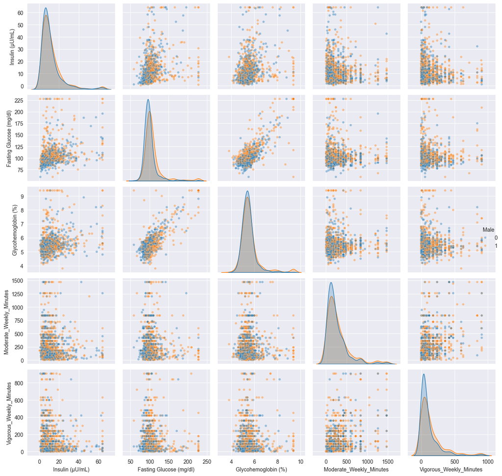

**What this visual shows and why it matters**  
The scatter‑plot matrix (SPLOM) presents pairwise relationships among insulin, glucose, glycohemoglobin, activity metrics, and gender.

- Off‑diagonal scatter points show the direction (positive/negative) and strength of relationships.
- Diagonal KDE curves summarise each variable’s distribution.
- Hue by gender uncovers potential sex‑specific trends.

### Heatmap to check correlations

### 🔥 Correlation Matrix

This block visualizes correlations between activity measures and biomarkers.

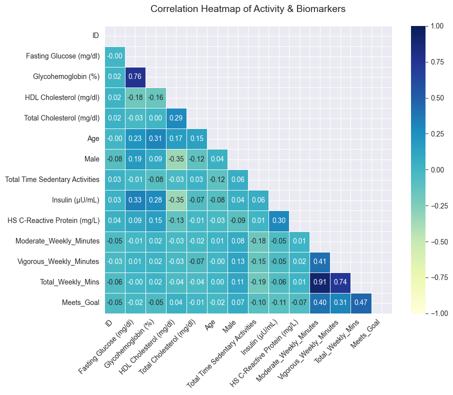

**What this visual shows and why it matters**  
This correlation heatmap displays Pearson correlations between all biomarkers and activity variables.

**How it helps the analysis**  
It pinpoints which biomarkers move together or in opposition, identifying candidates for multicollinearity checks and giving insight into potential causal pathways (e.g., sedentary time vs. CRP).

### Overlay Goal Line & Annotate in Matplotlib

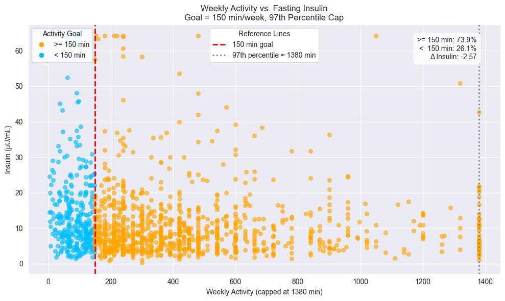

**What this visual shows and why it matters**  
This scatter plot demonstrates the relationship between weekly activity minutes and fasting insulin.

- **Red dashed line** = WHO guideline of 150 min/week.
- **Gray dotted line** = 97th‑percentile cap to reduce extreme points.
- Color groups instantly split participants meeting and not meeting the goal.
- The annotation box quantifies percent above/below goal and the insulin delta.

## Step 3: Dashboard Setup & Interactive Widgets

### 🖱️ Interactive Dashboard Setup

This block creates interactive dropdown widgets for exploratory analysis.

### 📝 Code Execution

This block performs a step in data processing or visualization.

**What this interactive visual offers**  
The dashboard lets reviewers choose an activity metric and biomarker, updating scatter, box, violin, and strip plots on the fly.

> **ℹ️ Static Snapshot:** This is a **static** PNG of the dashboard. To interact with the live dashboard, download the Jupyter notebook (`metabolic_health_analysis.ipynb`) and open it in Jupyter Notebook or JupyterLab after downloading the Datafiles as mentioned in the README

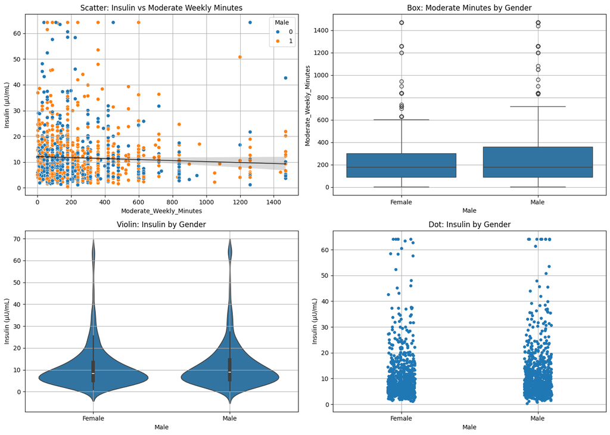

# Descriptions Section

## 🧠 Relevance to Human Health

**Understanding how physical activity influences key biomarkers is critical for promoting long‑term health.** These markers are directly linked to chronic diseases such as:

- **Type 2 Diabetes**
- **Cardiovascular Disease**
- **Metabolic Syndrome**
- **Obesity‑related Inflammation**

## 🔬 Impact of Physical Activity on Biomarkers

1. **Insulin (µU/mL)**
   - *Effect:* Improves insulin sensitivity
   - *Outcome:* Lower circulating insulin levels; reduced risk of insulin resistance and type 2 diabetes
2. **Fasting Glucose (mg/dL) & HbA1c (%)**
   - *Effect:* Enhances muscle glucose uptake
   - *Outcome:* Better blood glucose control; lower HbA1c values
3. **Cholesterol (HDL & Total)**
   - *Effect:* Increases HDL (“good” cholesterol); may reduce LDL and total cholesterol
   - *Outcome:* Improved heart health; reduced cardiovascular risk
4. **C‑Reactive Protein (CRP)**
   - *Effect:* Decreases systemic inflammation
   - *Outcome:* Lower CRP levels; protection against chronic diseases and improved immune function
5. **Sedentary Time**
   - *Effect:* Excessive sedentary behavior correlates with elevated insulin, worse lipid profiles, and higher CRP
   - *Outcome:* Provides a clear contrast between active and inactive lifestyles

## 📊 Market Analysis Layer

- **96 million U.S. adults** are prediabetic → Source: [CDC 2022 National Diabetes Statistics Report](https://www.cdc.gov/diabetes/data/statistics-report/index.html)
- **30% adoption** of activity nudges (e.g., walking prompts, step goals) → From digital health app engagement studies (JAMA, Nature Digital Medicine)
- **~5% reduction** in fasting insulin is associated with reduced diabetes risk → Clinical studies suggest even modest increases in physical activity improve insulin sensitivity
- **Assumption:** We reach 1 million preventable cases long term
- **Annual direct medical cost of diabetes:** ~$9,600 per person → Source: [ADA, 2022 Cost of Diabetes Report](https://diabetesjournals.org/care/article/46/4/454/148746)
- **Estimated cost savings:**
  - 1 million cases × $8,000–$10,000 per person = $8–$10 billion/year → Source: [ADA, 2022 Cost of Diabetes Report](https://diabetesjournals.org/care/article/46/4/454/148746)